# FIA - NLS Models: Biomass Growth vs. Stand Age, Temporally-balanced

## predict and plot

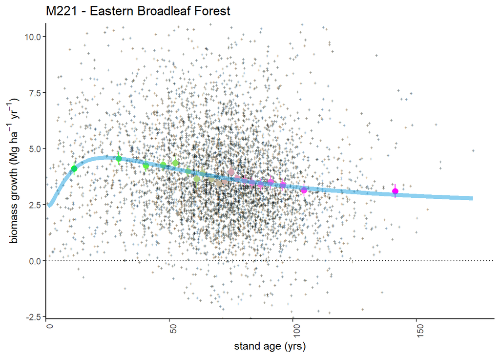

## plotting 2

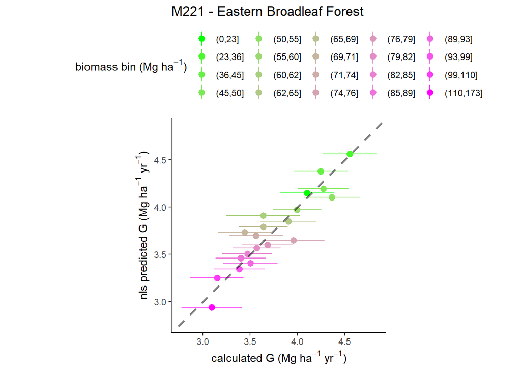

# M223 - Ozark Broadleaf Forest Meadow

## model selection 1

```
## Analysis of Variance Table
##
## Model 1: G_obs_TreeInc_MgHaYr ~ (1 + (MEASTIME_avg - 1990) * ge/100) * (a + b * exp(-((log(STDAGE_t1/c))/d)^2))
## Model 2: G_obs_TreeInc_MgHaYr ~ (1 + (MEASTIME_avg - 1990) * ge/100) * (1 + phi * DeltaPDSI) * (a + b * exp(-((log(STDAGE_t1/c))/d)^2))
## Model 3: G_obs_TreeInc_MgHaYr ~ (1 + (MEASTIME_avg - 1990) * ge/100) * (1 + phi * DeltaPDSI) * (1 - alpha * B_L_prop) * (a + b * exp(-((log(STDAGE_t1/c))/d)^2))
##   Res.Df Res.Sum Sq Df  Sum Sq F value    Pr(>F)
## 1    590     777.97
## 2    589     777.90  1  0.0774  0.0586    0.8088
## 3    588     754.35  1 23.5408 18.3495 2.148e-05 ***
## ---
## Signif. codes:  0 '***' 0.001 '**' 0.01 '*' 0.05 '.' 0.1 ' ' 1
##   model      AIC
## 1     1 2414.989
## 2     2 2416.930
## 3     3 2400.646
```

```
##
## Formula: G_obs_TreeInc_MgHaYr ~ (1 + (MEASTIME_avg - 1990) * ge/100) *
##     (1 + phi * DeltaPDSI) * (1 - alpha * B_L_prop) * (a + b *
##     exp(-((log(STDAGE_t1/c))/d)^2))
##
## Parameters:
##        Estimate Std. Error t value Pr(>|t|)
## ge     2.249314   1.435495   1.567  0.11767
## phi   -0.003053   0.029934  -0.102  0.91881
## alpha  0.868719   0.188816   4.601 5.16e-06 ***
## a      1.772977   0.357986   4.953 9.58e-07 ***
## b      1.318619   0.465128   2.835  0.00474 **
## c     24.976806   2.471727  10.105  < 2e-16 ***
## d      0.432758   0.127146   3.404  0.00071 ***
## ---
## Signif. codes:  0 '***' 0.001 '**' 0.01 '*' 0.05 '.' 0.1 ' ' 1
##
## Residual standard error: 1.133 on 588 degrees of freedom
##
## Number of iterations to convergence: 14
## Achieved convergence tolerance: 7.702e-06
##   (1 observation deleted due to missingness)
```

### summary

- simple model: fits
- phi model: fits
- phi-alpha model: fits

## plot residuals

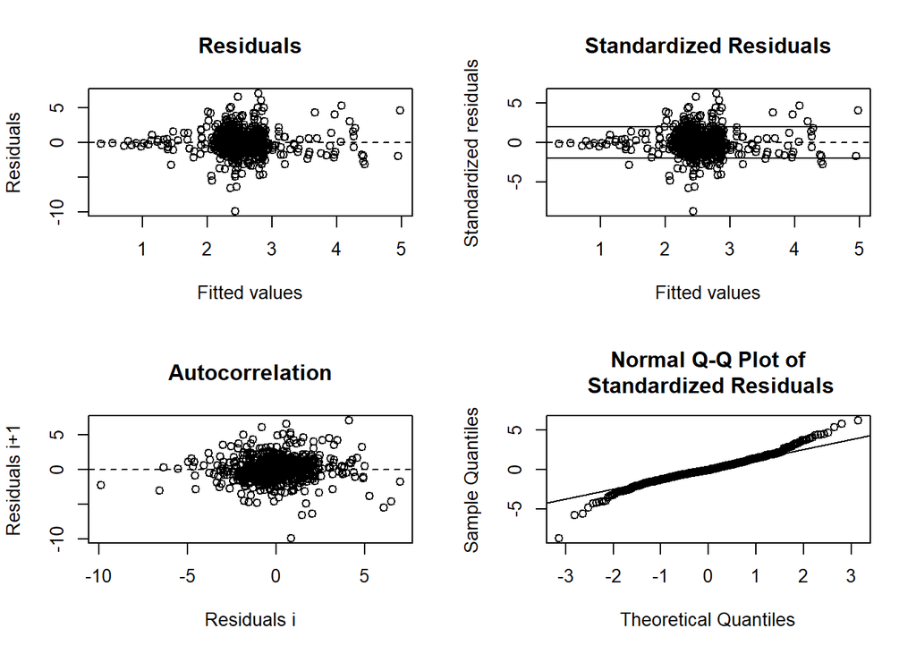

```
##
## ------
##  Shapiro-Wilk normality test
##
## data:  stdres
## W = 0.96861, p-value = 5.631e-10
##
##
## ------
```

```
##
##  Runs Test
##
## data:  as.factor(run)
## Standard Normal = -0.64105, p-value = 0.5215
## alternative hypothesis: two.sided
```

## predict and plot

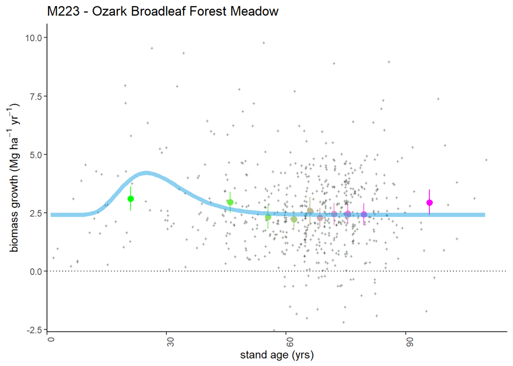

## plotting 2

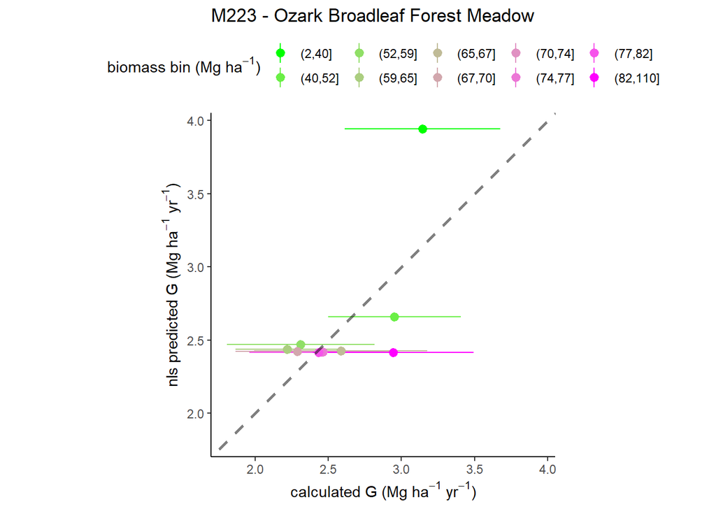

# M231 - Ouachita Mixed Forest

## model selection 1

```
## Error in numericDeriv(form[[3L]], names(ind), env, central = nDcentral) :
##   Missing value or an infinity produced when evaluating the model
```

```
## Error in numericDeriv(form[[3L]], names(ind), env, central = nDcentral) :
##   Missing value or an infinity produced when evaluating the model
```

[output not shown]

```
## Error in h(simpleError(msg, call)) :
##   error in evaluating the argument 'object' in selecting a method for function 'summary': object 'nls_M231.' not found
```

### summary

- simple model: does not fit
- phi model: does not fit
- phi-alpha model: does not fit

## plot residuals

```
## [1] "cannot plot residuals"
```

## predict and plot

```
## [1] "cannot plot data with prediction"
```

## plotting 2

# M242 - Cascade Mixed Forest

## model selection 1

### summary

- simple model: does not fit
- phi model: does not fit
- phi-alpha model: does not fit

## plot residuals

```
## [1] "cannot plot residuals"
```

## predict and plot

```
## [1] "cannot plot data with prediction"
```

## plotting 2

# M261 - Sierran Steppe - Mixed Forest - Coniferous Forest - Alpine Meadow

## model selection 1

[output not shown]

```
## Error in h(simpleError(msg, call)) :
##   error in evaluating the argument 'object' in selecting a method for function 'summary': object 'nls_M261.' not found
```

### summary

- simple model: does not fit
- phi model: does not fit
- phi-alpha model: does not fit

## plot residuals

```
## [1] "cannot plot residuals"
```

## predict and plot

```
## [1] "cannot plot data with prediction"
```

## plotting 2

# M262 - Califormia Coastal Range = Coniferous Forest - Open woodland Shrub Meadow

## model selection 1

### summary

- simple model: does not fit
- phi model: does not fit
- phi-alpha model: does not fit

## plot residuals

```
## [1] "cannot plot residuals"
```

## predict and plot

```
## [1] "cannot plot data with prediction"
```

## plotting 2

# M313 - Arizona-New Mexico Mountains Semi-Desert - Open Woodland - Coniferous Forest - Alpine Meadow

## model selection 1

[output not shown]

```
## Error in h(simpleError(msg, call)) :
##   error in evaluating the argument 'object' in selecting a method for function 'summary': object 'nls_M313.' not found
```

### summary

- simple model: does not fit
- phi model: does not fit
- phi-alpha model: does not fit

## plot residuals

```
## [1] "cannot plot residuals"
```

## predict and plot

```
## [1] "cannot plot data with prediction"
```

## plotting 2

# M331 - Southern Rocky Mountain Steppe - Open Woodland - Coniferous Forest - Alpine Meadow

## model selection 1

[output not shown]

```
## Error in h(simpleError(msg, call)) :
##   error in evaluating the argument 'object' in selecting a method for function 'summary': object 'nls_M331.' not found
```

### summary

- simple model: does not fit
- phi model: does not fit
- phi-alpha model: does not fit

## plot residuals

```
## [1] "cannot plot residuals"
```

## predict and plot

```
## [1] "cannot plot data with prediction"
```

## plotting 2

# M332 - Middle Rocky Mountain Steppe - Coniferous Forest - Alpine Meadow

## model selection 1

### summary

- simple model: does not fit
- phi model: does not fit
- phi-alpha model: does not fit

## plot residuals

```
## [1] "cannot plot residuals"
```

## predict and plot

```
## [1] "cannot plot data with prediction"
```

## plotting 2

# M333 - Northern Rocky Mountain Steppe - Coniferous Forest - Alpine Meadow

## model selection 1

### summary

- simple model: does not fit
- phi model: does not fit
- phi-alpha model: does not fit

## plot residuals

```
## [1] "cannot plot residuals"
```

## predict and plot

```
## [1] "cannot plot data with prediction"
```

## plotting 2

# M334 - Black Hills Coniferous Forest

## model selection 1

### summary

- simple model: does not fit
- phi model: does not fit
- phi-alpha model: does not fit

## plot residuals

```
## [1] "cannot plot residuals"
```

## predict and plot

```
## [1] "cannot plot data with prediction"
```

## plotting 2

# M341 - Nevada-Utah Mountains Semi-Desert - Coniferous Forest - Alpine Meadow

## model selection 1

### summary

- simple model: does not fit
- phi model: does not fit
- phi-alpha model: does not fit

## plot residuals

```
## [1] "cannot plot residuals"
```

## predict and plot

```
## [1] "cannot plot data with prediction"
```

## plotting 2

# Fitted parameters

## Best / selected models by ecoprovince

| Code | Ecoregion | Sel.Mod |
| --- | --- | --- |
| 211 | Northeastern Mixed Forest | 3 |
| 212 | Laurentian Mixed Forest | 3 |
| 221 | Eastern Broadleaf Forest | NA |
| 222 | Midwest Broadleaf Forest | NA |
| 223 | Central Interior Broadleaf Forest | 3 |
| 231 | Southeastern Mixed Forest | 3 |
| 232 | Outer Coastal Plain Mixed Forest | 3 |
| 234 | Lower Mississippi Riverine Forest | 3 |
| 242 | Pacific Lowland Mixed Forest | NA |
| 251 | Prairie Parkland (Temperate) | NA |
| 255 | Prairie Parkland (Subtropical) | NA |
| 261 | California Coastal Chaparral Forest and Shrub | NA |
| 262 | California Dry Steppe | NA |
| 263 | California Coastal Steppe - Mixed Forest and Redwood Forest | NA |
| 313 | Colorado Plateau Semi-Desert | NA |
| 315 | Southwest Plateau and Plains Dry Steppe and Shrub | NA |
| 321 | Chihuahuan Semi-Desert | NA |
| 322 | American Semidesert and Desert | NA |
| 331 | Great Plains/Palouse Dry Steppe | NA |
| 332 | Great Plains Steppe | NA |
| 341 | Intermountain Semi-Desert and Desert | NA |
| 342 | Intermountain Semi-Desert | NA |
| 411 | Everglades | NA |
| M211 | Adirondack-New England Mixed forest - Coniferous Forest - Alpine Meadow | 3 |
| M221 | Central Appalachian Broadleaf Forest - Coniferous Forest - Meadow | 3 |
| M223 | Ozark Broadleaf Forest Meadow | 3 |
| M231 | Ouachita Mixed Forest | NA |
| M242 | Cascade Mixed Forest | NA |
| M261 | Sierran Steppe - Mixed Forest - Coniferous Forest - Alpine Meadow | NA |
| M262 | California Coastal Range Coniferous Forest - Open Woodland - Shrub - Meadow | NA |
| M313 | Arizona-New Mexico Mountains Semi-Desert - Open Woodland - Coniferous Forest - Alpine Meadow | NA |
| M331 | Southern Rocky Mountain Steppe - Open Woodland - Coniferous Forest - Alpine Meadow | NA |
| M332 | Middle Rocky Mountain Steppe - Coniferous Forest - Alpine Meadow | NA |
| M333 | Northern Rocky Mountain Steppe - Coniferous Forest - Alpine Meadow | NA |
| M334 | Black Hills Coniferous Forest | NA |
| M341 | Nevada-Utah Mountains Semi-Desert - Coniferous Forest - Alpine Meadow | NA |

## table by ecoprovince

| Code | Ecoregion | region | n.obs | n.plots | ge | ge.2.5 | ge.97.5 | phi | phi.2.5 | phi.97.5 | alpha | alpha.2.5 | alpha.97.5 | a | a.2.5 | a.97.5 | b | b.2.5 | b.97.5 | c | c.2.5 | c.97.5 | d | d.2.5 | d.97.5 |
| --- | --- | --- | --- | --- | --- | --- | --- | --- | --- | --- | --- | --- | --- | --- | --- | --- | --- | --- | --- | --- | --- | --- | --- | --- | --- |
| 211 | Northeastern Mixed Forest | east | 4776 | 2388 | 0.4002224 | 0.0389499 | 0.7614949 | 0.0025857 | -0.0073713 | 0.0125427 | 0.6264881 | 0.5530737 | 0.6999026 | -50.9629411 | -1601.813888 | 1499.888006 | 54.3187593 | -1496.5064813 | 1605.1439998 | 27.39755 | 21.95757 | 32.83752 | 12.9186726 | -174.0179995 | 199.8553448 |
| 212 | Laurentian Mixed Forest | east | 11688 | 5844 | 0.9331887 | 0.6092127 | 1.2571648 | 0.0295304 | 0.0219882 | 0.0370726 | 0.8246098 | 0.7732510 | 0.8759686 | 0.5312332 | -0.469588 | 1.532054 | 2.0325811 | 1.0511279 | 3.0140343 | 19.46376 | 17.63040 | 21.29711 | 2.4679581 | 1.5999617 | 3.3359545 |
| 221 | Eastern Broadleaf Forest | east | 5350 | 2675 | NA | NA | NA | NA | NA | NA | NA | NA | NA | NA | NA | NA | NA | NA | NA | NA | NA | NA | NA | NA | NA |
| 222 | Midwest Broadleaf Forest | east | 3248 | 1624 | NA | NA | NA | NA | NA | NA | NA | NA | NA | NA | NA | NA | NA | NA | NA | NA | NA | NA | NA | NA | NA |
| 223 | Central Interior Broadleaf Forest | east | 6046 | 3023 | -1.0150225 | -1.2408395 | -0.7892055 | -0.0165732 | -0.0308665 | -0.0022800 | 0.5658680 | 0.4749208 | 0.6568151 | 2.8515284 | 1.874505 | 3.828552 | 1.7705353 | 0.8272910 | 2.7137796 | 28.88831 | 24.39419 | 33.38243 | 1.3175126 | 0.6806075 | 1.9544177 |
| 231 | Southeastern Mixed Forest | east | 7532 | 3766 | -0.2594970 | -0.4716122 | -0.0473818 | -0.0039453 | -0.0139998 | 0.0061092 | 0.8651337 | 0.8140131 | 0.9162542 | 3.2020365 | 2.561811 | 3.842262 | 3.4776729 | 2.8767562 | 4.0785895 | 18.70626 | 17.61987 | 19.79265 | 1.4183687 | 1.1723853 | 1.6643521 |
| 232 | Outer Coastal Plain Mixed Forest | east | 7568 | 3784 | -0.0000839 | -0.2881867 | 0.2880188 | 0.0014705 | -0.0097870 | 0.0127279 | 0.8448265 | 0.7874777 | 0.9021753 | 3.5566268 | 3.257546 | 3.855707 | 2.4472072 | 2.1763124 | 2.7181019 | 16.50237 | 15.35577 | 17.64897 | 0.9476475 | 0.8067596 | 1.0885355 |
| 234 | Lower Mississippi Riverine Forest | east | 784 | 392 | 0.1193993 | -1.3508976 | 1.5896961 | 0.0140511 | -0.0379447 | 0.0660468 | 0.8448439 | 0.6456782 | 1.0440096 | 3.6445500 | 2.284115 | 5.004985 | 1.6832166 | 0.6265936 | 2.7398396 | 20.51864 | 12.56836 | 28.46893 | 0.8375496 | 0.0884655 | 1.5866337 |
| 242 | Pacific Lowland Mixed Forest | pacific | 0 | 0 | NA | NA | NA | NA | NA | NA | NA | NA | NA | NA | NA | NA | NA | NA | NA | NA | NA | NA | NA | NA | NA |
| 251 | Prairie Parkland (Temperate) | east | 1248 | 624 | NA | NA | NA | NA | NA | NA | NA | NA | NA | NA | NA | NA | NA | NA | NA | NA | NA | NA | NA | NA | NA |
| 255 | Prairie Parkland (Subtropical) | pacific | 410 | 205 | NA | NA | NA | NA | NA | NA | NA | NA | NA | NA | NA | NA | NA | NA | NA | NA | NA | NA | NA | NA | NA |
| 261 | California Coastal Chaparral Forest and Shrub | pacific | 0 | 0 | NA | NA | NA | NA | NA | NA | NA | NA | NA | NA | NA | NA | NA | NA | NA | NA | NA | NA | NA | NA | NA |
| 262 | California Dry Steppe | pacific | 0 | 0 | NA | NA | NA | NA | NA | NA | NA | NA | NA | NA | NA | NA | NA | NA | NA | NA | NA | NA | NA | NA | NA |
| 263 | California Coastal Steppe - Mixed Forest and Redwood Forest | pacific | 0 | 0 | NA | NA | NA | NA | NA | NA | NA | NA | NA | NA | NA | NA | NA | NA | NA | NA | NA | NA | NA | NA | NA |
| 313 | Colorado Plateau Semi-Desert | interior west | 0 | 0 | NA | NA | NA | NA | NA | NA | NA | NA | NA | NA | NA | NA | NA | NA | NA | NA | NA | NA | NA | NA | NA |
| 315 | Southwest Plateau and Plains Dry Steppe and Shrub | interior west | 0 | 0 | NA | NA | NA | NA | NA | NA | NA | NA | NA | NA | NA | NA | NA | NA | NA | NA | NA | NA | NA | NA | NA |
| 321 | Chihuahuan Semi-Desert | interior west | 0 | 0 | NA | NA | NA | NA | NA | NA | NA | NA | NA | NA | NA | NA | NA | NA | NA | NA | NA | NA | NA | NA | NA |
| 322 | American Semidesert and Desert | interior west | 0 | 0 | NA | NA | NA | NA | NA | NA | NA | NA | NA | NA | NA | NA | NA | NA | NA | NA | NA | NA | NA | NA | NA |
| 331 | Great Plains/Palouse Dry Steppe | interior west | 104 | 52 | NA | NA | NA | NA | NA | NA | NA | NA | NA | NA | NA | NA | NA | NA | NA | NA | NA | NA | NA | NA | NA |
| 332 | Great Plains Steppe | interior west | 132 | 66 | NA | NA | NA | NA | NA | NA | NA | NA | NA | NA | NA | NA | NA | NA | NA | NA | NA | NA | NA | NA | NA |
| 341 | Intermountain Semi-Desert and Desert | interior west | 0 | 0 | NA | NA | NA | NA | NA | NA | NA | NA | NA | NA | NA | NA | NA | NA | NA | NA | NA | NA | NA | NA | NA |
| 342 | Intermountain Semi-Desert | interior west | 2 | 1 | NA | NA | NA | NA | NA | NA | NA | NA | NA | NA | NA | NA | NA | NA | NA | NA | NA | NA | NA | NA | NA |
| 411 | Everglades | east | 64 | 32 | NA | NA | NA | NA | NA | NA | NA | NA | NA | NA | NA | NA | NA | NA | NA | NA | NA | NA | NA | NA | NA |
| M211 | Adirondack-New England Mixed forest - Coniferous Forest - Alpine Meadow | east | 5068 | 2534 | 0.9822530 | 0.5628390 | 1.4016671 | 0.0175635 | 0.0084902 | 0.0266369 | 0.6263468 | 0.5637669 | 0.6889266 | 2.3371744 | 2.032996 | 2.641353 | 0.7232093 | 0.5024181 | 0.9440005 | 28.93664 | 24.72814 | 33.14513 | 0.9981749 | 0.5942495 | 1.4021004 |
| M221 | Central Appalachian Broadleaf Forest - Coniferous Forest - Meadow | east | 5104 | 2552 | -0.4023827 | -0.6953812 | -0.1093843 | -0.0206422 | -0.0345617 | -0.0067228 | 0.7441258 | 0.6269297 | 0.8613220 | 2.7775694 | 1.456422 | 4.098717 | 2.5609416 | 1.3432459 | 3.7786373 | 24.50048 | 20.41972 | 28.58123 | 1.4854871 | 0.7837899 | 2.1871843 |
| M223 | Ozark Broadleaf Forest Meadow | east | 596 | 298 | 2.2493138 | -0.5700088 | 5.0686364 | -0.0030526 | -0.0618438 | 0.0557385 | 0.8687188 | 0.4978829 | 1.2395546 | 1.7729772 | 1.069891 | 2.476064 | 1.3186189 | 0.4051042 | 2.2321335 | 24.97681 | 20.12232 | 29.83129 | 0.4327580 | 0.1830418 | 0.6824743 |
| M231 | Ouachita Mixed Forest | east | 668 | 334 | NA | NA | NA | NA | NA | NA | NA | NA | NA | NA | NA | NA | NA | NA | NA | NA | NA | NA | NA | NA | NA |
| M242 | Cascade Mixed Forest | pacific | 6 | 3 | NA | NA | NA | NA | NA | NA | NA | NA | NA | NA | NA | NA | NA | NA | NA | NA | NA | NA | NA | NA | NA |
| M261 | Sierran Steppe - Mixed Forest - Coniferous Forest - Alpine Meadow | pacific | 0 | 0 | NA | NA | NA | NA | NA | NA | NA | NA | NA | NA | NA | NA | NA | NA | NA | NA | NA | NA | NA | NA | NA |
| M262 | California Coastal Range Coniferous Forest - Open Woodland - Shrub - Meadow | interior west | 0 | 0 | NA | NA | NA | NA | NA | NA | NA | NA | NA | NA | NA | NA | NA | NA | NA | NA | NA | NA | NA | NA | NA |
| M313 | Arizona-New Mexico Mountains Semi-Desert - Open Woodland - Coniferous Forest - Alpine Meadow | interior west | 0 | 0 | NA | NA | NA | NA | NA | NA | NA | NA | NA | NA | NA | NA | NA | NA | NA | NA | NA | NA | NA | NA | NA |
| M331 | Southern Rocky Mountain Steppe - Open Woodland - Coniferous Forest - Alpine Meadow | interior west | 0 | 0 | NA | NA | NA | NA | NA | NA | NA | NA | NA | NA | NA | NA | NA | NA | NA | NA | NA | NA | NA | NA | NA |
| M332 | Middle Rocky Mountain Steppe - Coniferous Forest - Alpine Meadow | interior west | 2 | 1 | NA | NA | NA | NA | NA | NA | NA | NA | NA | NA | NA | NA | NA | NA | NA | NA | NA | NA | NA | NA | NA |
| M333 | Northern Rocky Mountain Steppe - Coniferous Forest - Alpine Meadow | interior west | 0 | 0 | NA | NA | NA | NA | NA | NA | NA | NA | NA | NA | NA | NA | NA | NA | NA | NA | NA | NA | NA | NA | NA |
| M334 | Black Hills Coniferous Forest | interior west | 290 | 145 | NA | NA | NA | NA | NA | NA | NA | NA | NA | NA | NA | NA | NA | NA | NA | NA | NA | NA | NA | NA | NA |
| M341 | Nevada-Utah Mountains Semi-Desert - Coniferous Forest - Alpine Meadow | interior west | 0 | 0 | NA | NA | NA | NA | NA | NA | NA | NA | NA | NA | NA | NA | NA | NA | NA | NA | NA | NA | NA | NA | NA |

## plot ge

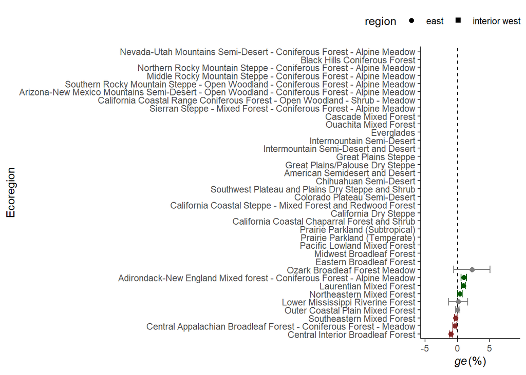

### map

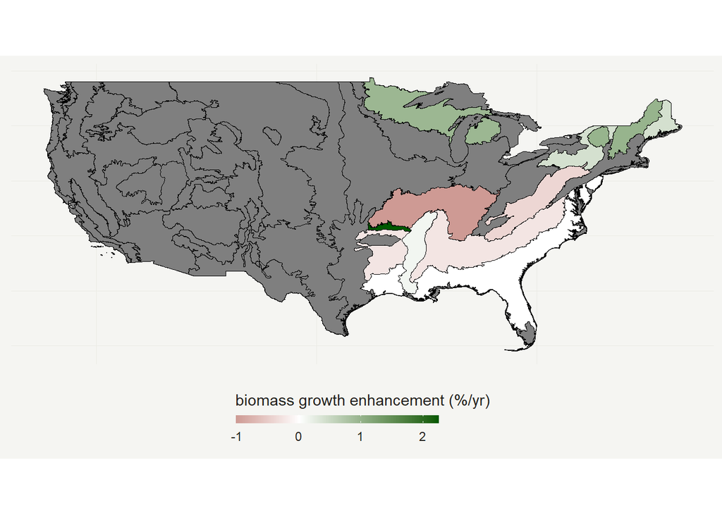

### map2

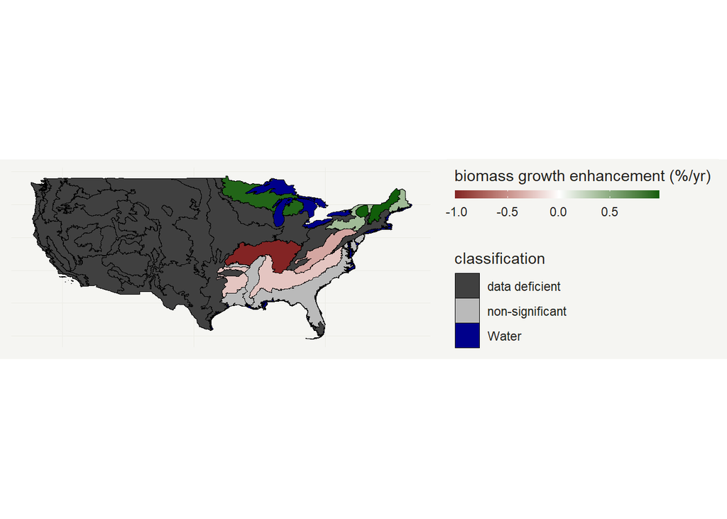

## plot phi (effect of DeltaPDSI)

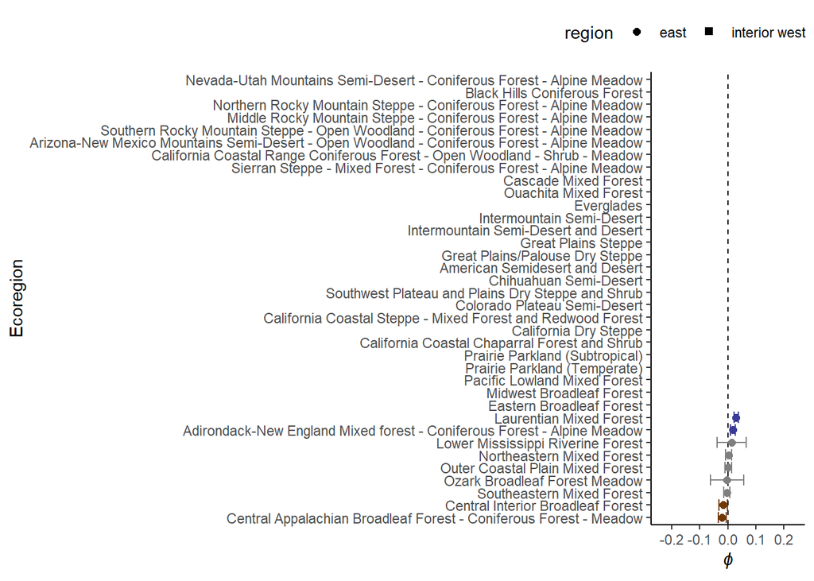

## plot alpha (biomass growth compensation effect)

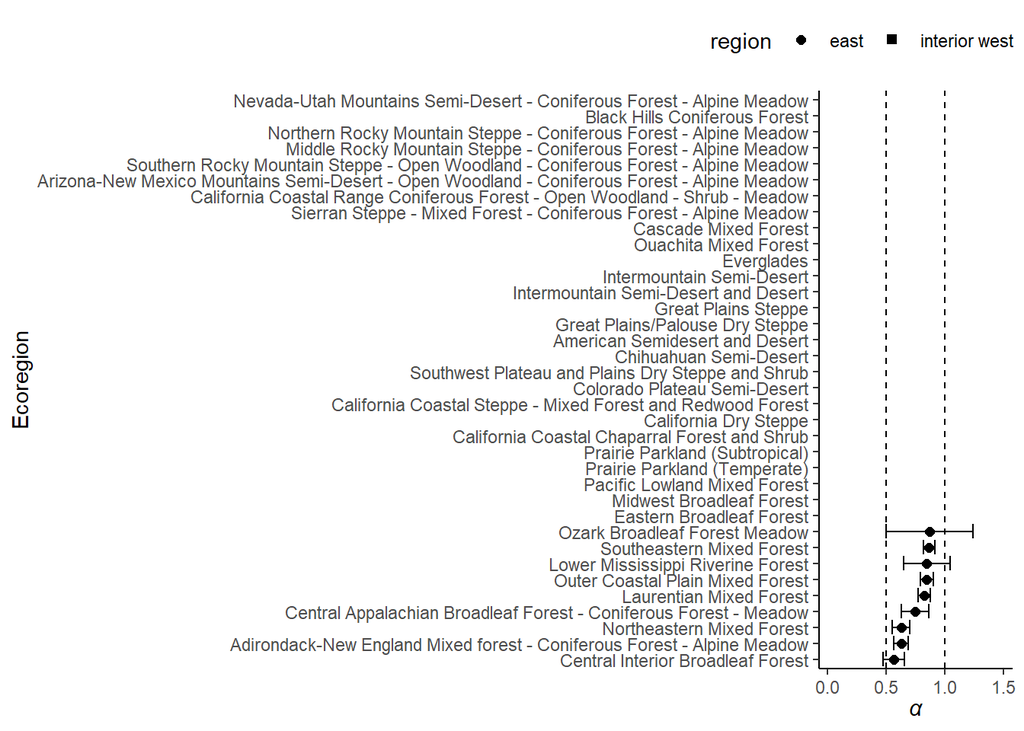